# 35 - Identify drivers to improve scoring per hotel

Jens Linden

STATUS: Development

# 1 Management summary

Build regression trees (with target being review score) for each hotel individually. The tree can reveal insights, where the hotel can improve, in order to obtain better ratings.

# 2 Inits

Initialisations and loading of libraries required:

```r
rm(list=ls())   # clear all
graphics.off()  # close all
Sys.setenv(LANG = "en")
# Libs
# library(checkpoint) # Package management to avoid incompatibilities; not required when dockerized
# checkpoint('2017-10-01') # Use all packages as of date provided
library(data.table) # Efficient and fast data munging in R; just do it
options(datatable.auto.index=FALSE) # Bug fixing for v < 1.9.5
library(ggplot2) # Good quality plots
library(rprojroot) # Rroot folder management
ROOT <- find_root(has_file("PROJECT_ROOT_DIR"))
library(caret) # Classification And REgression Training
source(paste0(ROOT, "/02_code/lib.R"))
options(width = 100)
```

# 3 Load data

```r
# Analytics base table (ABT) for hotels
(abt_hot <- readRDS(paste0(ROOT, '/01_data/03_preprocessed/abt_hot.rds')))
```

```
##       id_hot dist_city_centre Total_Number_of_Reviews      city
##    1:      1        2330.9926                    1403 Amsterdam
##    2:      2        5690.9030                    1831    London
##    3:      3         777.3218                    2619    London
##    4:      4        4378.4431                    4380    London
##    5:      5        4982.8083                     171     Paris
##   ---
## 1473:   1490        1855.7287                    3461    Vienna
## 1474:   1491         604.7996                     717    Vienna
## 1475:   1492        2882.8540                     232    London
## 1476:   1493        5297.5589                    5945    London
## 1477:   1494        2176.0265                    2823    Vienna
```

```r
# Hotel clusters from analysis 30
(clus_hot <- readRDS(paste0(ROOT, '/01_data/04_results/30_hotel_cluster.rds')))
```

```
##       id_hot clus
##    1:      1    5
##    2:      2    1
##    3:      3    3
##    4:      4    4
##    5:      5    1
##   ---
## 1473:   1490    4
## 1474:   1491    3
## 1475:   1492    5
## 1476:   1493    4
## 1477:   1494    4
```

```r
# Analytics base table (ABT) for reviews
(abt_rev <- readRDS(paste0(ROOT, '/01_data/03_preprocessed/abt_rev.rds')))
```

```
##                                   id_rev id_hot    month n_nights     trip_type is_mobile_device
##      1: 0000021f16f34e83f3c00f7c1e8ce342    424  Februar        1 business trip               no
##      2: 00001a70c8aafd8b629de382a9e56a5d    981      Mai        8 business trip              yes
##      3: 000026bf2118dd993ac3fe193e44bc66    487     März        1  leisure trip              yes
##      4: 00002f5267fe6e9f4ed0d3c31a4d6388   1025 Dezember        2  leisure trip              yes
##      5: 00003e7067fd3c681b86f6d576b1f03d    617     Juli        1 business trip               no
##     ---
## 515207: ffff3c0921d9a8e3bbff7bcf28053d5a   1124   August        2       unknown              yes
## 515208: ffff5c19d56ee3324f2c1bc030324ea2    310 Dezember        2  leisure trip               no
## 515209: ffff6193b3e00f992a63a3c812e9137e   1178     Juli        3  leisure trip              yes
## 515210: ffff82261013e152f41cb939f0121401    799     Juli        3  leisure trip               no
## 515211: ffffc8f6f66e7beccec01579237ae668   1021     Juli        2  leisure trip              yes
##                         group_type is_superior_room room_size
##      1:              solo traveler               no    double
##      2:              solo traveler              yes    single
##      3:                     couple               no    double
##      4:                     couple               no    double
##      5:              solo traveler               no    double
##     ---
## 515207: family with young children               no    double
## 515208:                      group               no   unknown
## 515209:                     couple               no    double
## 515210:                     couple               no    double
## 515211:                     couple              yes    double
```

```r
# Review data
(rev <- readRDS(paste0(ROOT, '/01_data/03_preprocessed/reviews.rds')))
```

```
##                 Hotel_Name
##      1: 11 Cadogan Gardens
##      2: 11 Cadogan Gardens
##      3: 11 Cadogan Gardens
##      4: 11 Cadogan Gardens
##      5: 11 Cadogan Gardens
##     ---
## 515207:  pentahotel Vienna
## 515208:  pentahotel Vienna
## 515209:  pentahotel Vienna
## 515210:  pentahotel Vienna
## 515211:  pentahotel Vienna
##                                                                                 Hotel_Address
##      1: 11 Cadogan Gardens Sloane Square Kensington and Chelsea London SW3 2RJ United Kingdom
##      2: 11 Cadogan Gardens Sloane Square Kensington and Chelsea London SW3 2RJ United Kingdom
```

[output cut: 129 more lines]

# 4 Preprocessing

## 4.1 Add cluster of hotel hotel ABT

```r
# Join on hotel ID
abt_hot <- merge(abt_hot,
                 clus_hot,
                 by = 'id_hot')
```

## 4.2 Add variables to review ABT

```r
abt_rev <- merge(abt_rev,
                 rev[, .(id_rev, Total_Number_of_Reviews_Reviewer_Has_Given, Reviewer_Score)],
                 by = 'id_rev')
# Inspect
abt_rev[1:3]
```

```
##                              id_rev id_hot   month n_nights     trip_type is_mobile_device
## 1: 0000021f16f34e83f3c00f7c1e8ce342    424 Februar        1 business trip               no
## 2: 00001a70c8aafd8b629de382a9e56a5d    981     Mai        8 business trip              yes
## 3: 000026bf2118dd993ac3fe193e44bc66    487    März        1  leisure trip              yes
##       group_type is_superior_room room_size Total_Number_of_Reviews_Reviewer_Has_Given
## 1: solo traveler               no    double                                          1
## 2: solo traveler              yes    single                                          4
## 3:        couple               no    double                                          6
##    Reviewer_Score
## 1:            9.6
## 2:            9.6
## 3:            6.3
```

## 4.3 Convert variable types

```r
# Identify character columns
(cols_char <- setdiff(dt_classes(abt_rev)[class == 'character', col], 'id_rev'))
```

```
## [1] "month"            "trip_type"        "is_mobile_device" "group_type"       "is_superior_room"
## [6] "room_size"
```

```r
# Convert to factors (categorical variables)
abt_rev[, (cols_char) := lapply(.SD, as.factor), .SDcols = cols_char]
# Check if worked
dt_classes(abt_rev)
```

```
##                                            col     class
##  1:                                     id_rev character
##  2:                                     id_hot   integer
##  3:                                      month    factor
##  4:                                   n_nights   numeric
##  5:                                  trip_type    factor
##  6:                           is_mobile_device    factor
##  7:                                 group_type    factor
##  8:                           is_superior_room    factor
##  9:                                  room_size    factor
## 10: Total_Number_of_Reviews_Reviewer_Has_Given   integer
## 11:                             Reviewer_Score   numeric
```

# 5 Regression tree for single hotel

Use a regression tree to model the reviewer score for each hotel indiviudally. Using `ctree` implementation of `party` package, as this allows to specify a minimum p-value for each split. The regression tree allows to deduce insights, where a hotel could improve to increase the ratings hence customer satisfaction, which will influence future revenue.

## 5.1 Settings for modeling

```r
s <- list()
# Define hotel of interest
s$id_hot <- 3
# Define target variable
s$target <- 'Reviewer_Score'
# Define features
(s$feat <- setdiff(names(abt_rev), c('id_rev', 'id_hot', s$target)))
```

```
## [1] "month"                                      "n_nights"
## [3] "trip_type"                                  "is_mobile_device"
## [5] "group_type"                                 "is_superior_room"
## [7] "room_size"                                  "Total_Number_of_Reviews_Reviewer_Has_Given"
```

## 5.2 Check for zero variance predictors

```r
(idx_nzv <- nearZeroVar(abt_rev[id_hot == s$id_hot, s$feat, with = F]))
```

```
## integer(0)
```

## 5.3 Check for correltated predictors

```r
x <- model.matrix(
  as.formula(paste0(s$target, " ~ .")),
  data = abt_rev[id_hot == s$id_hot, c(s$target, s$feat), with = F]
)[, -1]
(idx_cor <- findCorrelation(cor(x)))
```

```
## integer(0)
```

## 5.4 Check for missing data

```r
sum(!complete.cases(abt_rev[id_hot == s$id_hot, c(s$target, s$feat), with = F]))
```

```
## [1] 0
```

## 5.5 Build regression tree

```r
set.seed(123) # Random seed to create reproducible results
# Use resamling using bootstrap method to validate model
ctrl <- trainControl(method = "boot",
                     number = 50)
grid <- expand.grid(.mincriterion = .95, # request a p-value of 0.05 for each split
                    .maxdepth =  as.integer(1:3))
fit <- train(
    x = abt_rev[id_hot == s$id_hot, s$feat, with = F],
    y = abt_rev[id_hot == s$id_hot, get(s$target)],
    method = "ctree2", # rpart, rpart1SE
    trControl = ctrl,
    # controls = ctree_control(minbucket = 50),
    metric = "Rsquared", # Accuracy
    tuneGrid = grid) # set to NULL to swich off tuning grid
# Inspect model
print(fit)
```

```
## Conditional Inference Tree
##
## 1037 samples
##    8 predictor
##
## No pre-processing
## Resampling: Bootstrapped (50 reps)
## Summary of sample sizes: 1037, 1037, 1037, 1037, 1037, 1037, ...
## Resampling results across tuning parameters:
##
##   maxdepth  RMSE       Rsquared     MAE
##   1         0.9301881  0.009443052  0.6691993
##   2         0.9358130  0.011231564  0.6714314
##   3         0.9394210  0.011537561  0.6726495
##
## Tuning parameter 'mincriterion' was held constant at a value of 0.95
## Rsquared was used to select the optimal model using the largest value.
## The final values used for the model were maxdepth = 3 and mincriterion = 0.95.
```

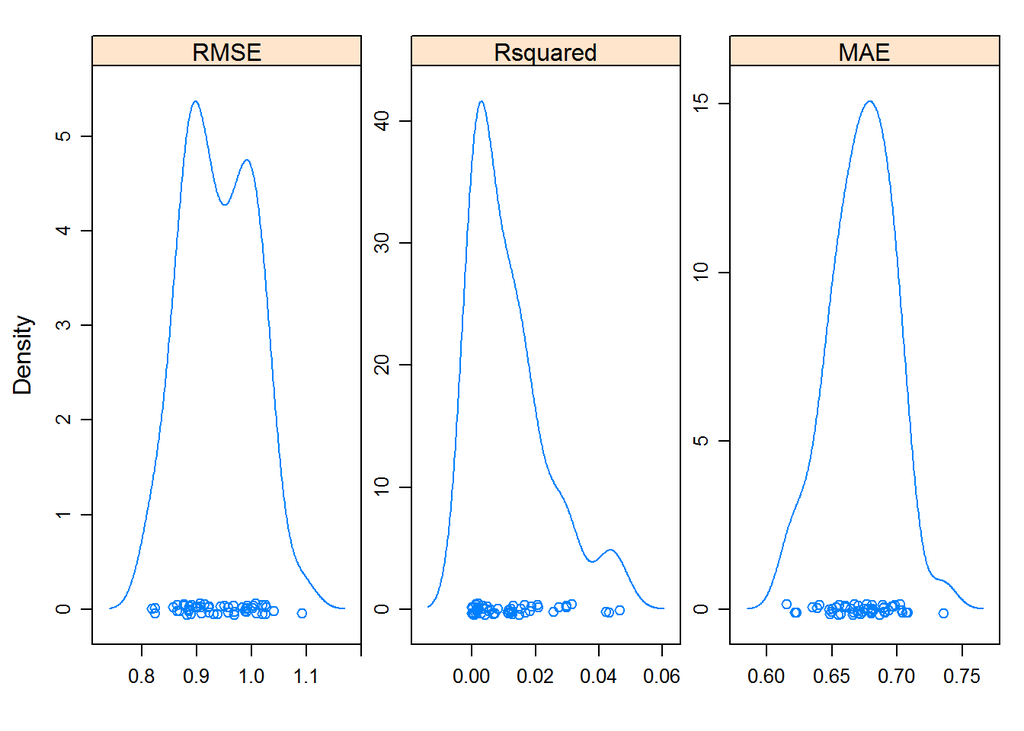

```r
resampleHist(fit)
```

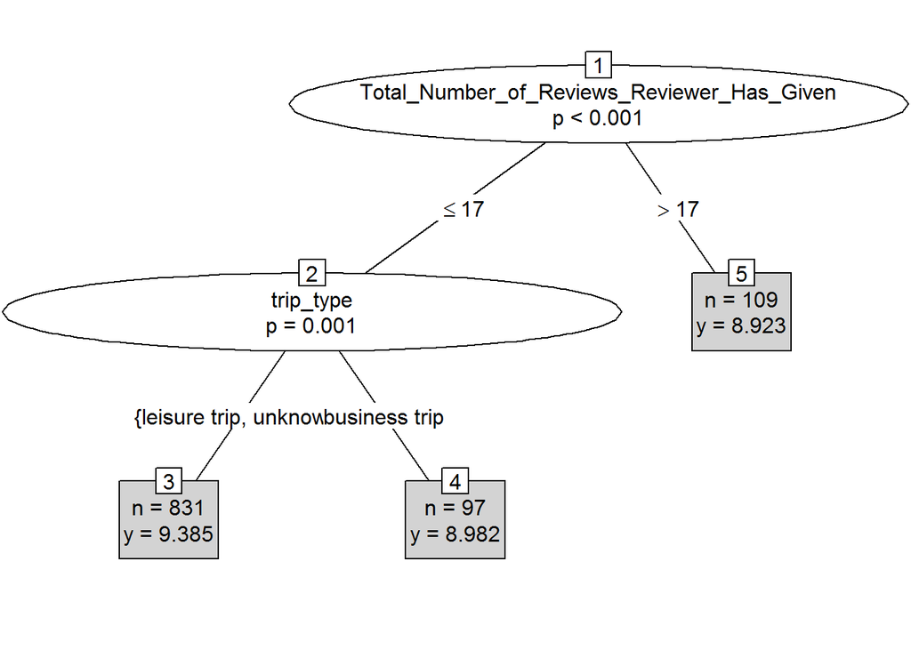

```r
# plot final model
plot(fit$finalModel, type = "simple")
```

## 5.6 Conclusion

As expected the $R^2$ value for the regression tree is quite low. Nethertheless, as long as splits are statistically significant, the tree model can be used to deduce insights, where the hotel can improve. In this particular case for hotel #3, business travellers tend to give lower ratings (albeit overall still high with 8.9 on average). This information could be used to make the hotel more attractive for business travellers. Note, however, that the majority of reviewers are non-business travellers.